# Introduction to R Programming

07/06/2017

## R basics

## Materials

You can find the materials for today's course on my website. Either go to the Moodle page for MY591 and click on the links, or:

- Assignment: jackblumenau.com/assignment.html
- Slides: jackblumenau.com/introtor.html

It is worth noting that both the assignment and the slides were all created using R and RStudio. So was my website.

Beat that, STATA…

## I have used STATA for years, why learn R?

Because:

- R is free
- R is open source and has excellent package support and development
- R is (easily) customisable
- R is *very* good for data visualisation
- R can accomodate more than one data matrix in memory at the same time
- You are about to learn some methods that are basically only available in R

On the other hand:

- R has a steep(er) learning curve

## R and RStudio

- As in STATA, you can either write commands directly into the console, or use a script (do file) to save commands and then run them
- It is perfectly possible to use the base R environment for everything, but most people do not do this
- Today we will mostly be using RStudio, which is a graphical user interface (GUI) for R
- RStudio has a host of useful features which make it an excellent environment for learning R
  - Syntax highlighting
  - Easy data overview
  - Looks a bit like STATA…

## RStudio demonstration

## Basic operations in R

```r
1 + 1
```

```
## [1] 2
```

```r
5 - 3
```

```
## [1] 2
```

```r
6/2
```

```
## [1] 3
```

```r
4*4
```

```
## [1] 16
```

## Basic operations in R

- Other typical mathematical functions are also hard-coded:

```r
log(<number>)
exp(<number>)
sqrt(<number>)
mean(<numbers>)
sum(<numbers>)
```

## Basic operations in R

R also understands logical operators:

- `<` : less than
- `>` : greater than
- `==` : equal to (note, not `=`)
- `>=` : greater than or equal to
- `<=` : less than or equal to
- `!=` : not equal to
- `&` : and
- `|` : or

## R `objects`

- R is an object-oriented programming language
- The entities that R creates and manipulates are known as objects
- These may be variables, arrays of numbers, character strings, functions
- Objects are created using the *assignment operator*: `<-`
- Once created, an object is stored in your current *workspace*

```r
my_object <- 10
print(my_object)
```

```
## [1] 10
```

```r
my_other_object <- 4
print(my_object - my_other_object)
```

```
## [1] 6
```

## Data Structures

## `vector` - the basic building block of R.

A vector is a collection of entites which all share the same type.

We use the `c()` function to concatenate observations into a single vector.

- Numeric

```r
num_vec <- c(5, 4, 2, 100, 7.65)
print(num_vec)
```

```
## [1]   5.00   4.00   2.00 100.00   7.65
```

- Character

```r
char_vec <- c("apple", "pear", "plumb", "pineapple", "strawberry")
print(char_vec)
```

```
## [1] "apple"      "pear"       "plumb"      "pineapple"  "strawberry"
```

## `vector` - the basic building block of R.

- Logical

```r
log_vec <- c(FALSE, FALSE, FALSE, TRUE, TRUE)
print(log_vec)
```

```
## [1] FALSE FALSE FALSE  TRUE  TRUE
```

```r
as.numeric(log_vec)
```

```
## [1] 0 0 0 1 1
```

## `vector` - the basic building block of R.

- Factor

A factor is similar to a character vector, but here each unique element is associated with a numerical value which represents a category:

```r
fac_vec <- as.factor(c("a", "b","c","a","b","c"))
fac_vec
```

```
## [1] a b c a b c
## Levels: a b c
```

```r
as.numeric(fac_vec)
```

```
## [1] 1 2 3 1 2 3
```

## `vector` subsetting

To subset a `vector`, use square parenthesis to index the elements you would like via `object[index]`:

- Numerical subsetting

```r
char_vec
```

```
## [1] "apple"      "pear"       "plumb"      "pineapple"  "strawberry"
```

```r
char_vec[1:3]
```

```
## [1] "apple" "pear"  "plumb"
```

## `vector` subsetting

- Logical subsetting

```r
log_vec
```

```
## [1] FALSE FALSE FALSE  TRUE  TRUE
```

```r
char_vec[log_vec]
```

```
## [1] "pineapple"  "strawberry"
```

## `vector` operations

In R, mathematical operations on vectors occur elementwise:

```r
fib <- c(1, 1, 2, 3, 5, 8, 13, 21)
fib[1:7]
```

```
## [1]  1  1  2  3  5  8 13
```

```r
fib[2:8]
```

```
## [1]  1  2  3  5  8 13 21
```

```r
fib[1:7] + fib[2:8]
```

```
## [1]  2  3  5  8 13 21 34
```

## `vector` operations

It is also possible to perform logical operations on vectors:

```r
fib <- c(1, 1, 2, 3, 5, 8, 13, 21)
fib_greater_five <- fib > 5
print(fib_greater_five)
```

```
## [1] FALSE FALSE FALSE FALSE FALSE  TRUE  TRUE  TRUE
```

And we can combine logical operators

```r
fib_greater_five_less_two <- fib > 5 | fib < 2
print(fib_greater_five_less_two)
```

```
## [1]  TRUE  TRUE FALSE FALSE FALSE  TRUE  TRUE  TRUE
```

## `matrix`

A matrix is just a collection of vectors! I.e. it is a multidimensional vector where all elements are of the same type

```r
my_matrix <- matrix(data = 1:100, nrow = 10, ncol = 10)
my_matrix
```

```
##       [,1] [,2] [,3] [,4] [,5] [,6] [,7] [,8] [,9] [,10]
##  [1,]    1   11   21   31   41   51   61   71   81    91
##  [2,]    2   12   22   32   42   52   62   72   82    92
##  [3,]    3   13   23   33   43   53   63   73   83    93
##  [4,]    4   14   24   34   44   54   64   74   84    94
##  [5,]    5   15   25   35   45   55   65   75   85    95
##  [6,]    6   16   26   36   46   56   66   76   86    96
##  [7,]    7   17   27   37   47   57   67   77   87    97
##  [8,]    8   18   28   38   48   58   68   78   88    98
##  [9,]    9   19   29   39   49   59   69   79   89    99
## [10,]   10   20   30   40   50   60   70   80   90   100
```

## `data.frame`

A `data.frame` is a matrix-like R object in which the columns can be of different types

```r
my_data_frame <- data.frame(numbers = num_vec, fruits = char_vec, logical = log_vec)
my_data_frame
```

```
##   numbers     fruits logical
## 1    5.00      apple   FALSE
## 2    4.00       pear   FALSE
## 3    2.00      plumb   FALSE
## 4  100.00  pineapple    TRUE
## 5    7.65 strawberry    TRUE
```

## `matrix` and `data.frame` subsetting

To subset a `matrix` or `data.frame`, you need to specify both rows and columns:

```r
my_matrix[1:3, 1:3]
```

```
##      [,1] [,2] [,3]
## [1,]    1   11   21
## [2,]    2   12   22
## [3,]    3   13   23
```

```r
my_data_frame[1, ]
```

```
##   numbers fruits logical
## 1       5  apple   FALSE
```

## `matrix` and `data.frame` subsetting

We can also subset to remove rows or columns that we do not want to see by using the `-` operator applied to the `c` function:

```r
my_matrix[-c(1:3), -c(1:3)]
```

```
##      [,1] [,2] [,3] [,4] [,5] [,6] [,7]
## [1,]   34   44   54   64   74   84   94
## [2,]   35   45   55   65   75   85   95
## [3,]   36   46   56   66   76   86   96
## [4,]   37   47   57   67   77   87   97
## [5,]   38   48   58   68   78   88   98
## [6,]   39   49   59   69   79   89   99
## [7,]   40   50   60   70   80   90  100
```

In the code, `1:3` creates a vector of the integers 1, 2 and 3, and the `-` operator negates these. We wrap the vector in the `c` function so that `-` applies to each element, and not just the first element.

## `list`

A `list` is a collection of any set of object types

```r
my_list <- list(something = num_vec,
                another_thing = my_matrix[1:3,1:3],
                something_else = "jack")
my_list
```

```
## $something
## [1]   5.00   4.00   2.00 100.00   7.65
##
## $another_thing
##      [,1] [,2] [,3]
## [1,]    1   11   21
## [2,]    2   12   22
## [3,]    3   13   23
##
## $something_else
## [1] "jack"
```

## `functions`

R makes extensive use of functions, which all have the same basic structure.

```r
function_name(argument_one, argument_two, ...)
```

Where

- `function_name` is the name of the function
- `argument_one` is the first argument passed to the function
- `argument_two` is the seccond argument passed to the function

## `function` example

Let's consider the `mean()` function. This function takes two main arguments:

```r
mean(x, na.rm = FALSE)
```

Where `x` is a numeric vector, and `na.rm` is a logical value that indicates whether we'd like to remove missing values (`NA`).

```r
vec <- c(1,2,3,4,5)
mean(x = vec, na.rm = FALSE)
```

```
## [1] 3
```

```r
vec <- c(1,2,3,NA,5)
mean(x = vec, na.rm = TRUE)
```

```
## [1] 2.75
```

## `function` example

We can also perform calculations on the output of a function:

```r
mean(vec) * 3
```

```
## [1] 9
```

Which means that we can also have nested functions:

```r
sqrt(mean(vec))
```

```
## [1] 1.732051
```

We can also assign the output of any function to a new object for use later:

```r
sqrt_mean_of_vec <- sqrt(mean(vec))
```

## User defined `functions`

Functions are also objects, and we can create our own. We define a function as follows:

```r
my_addition_function <- function(a, b){
  return(a + b)
}

my_addition_result <- my_addition_function(a = 5, b = 50)
print(my_addition_result)
```

```
## [1] 55
```

Note that the function itself, and the result returned by the function are both objects!

## Help!

R has an inbuilt help facility which provides more information about any function:

```r
help(summary)
?summary
```

The quality of the help varies *hugely* as some packages are well-maintained and others less so.

Alternative sources of help:

`www.stackoverflow.com`

`www.google.com`

## Exercise One

## Data manipulation and exploration

## Reading data into R (.csv)

```r
my_data <- read.csv(file = "my_file.csv")
```

- `my_data` is an R data.frame object (you could call this anything)
- `my_file.csv` is a .csv file with your data
- `<-` is the assignment operator
- In order for R to access `my_file.csv`, it will have to be saved in your current working directory
- Use `get_wd()` to check your current working directory
- Use `set_wd()` to change your current working directory

## Reading data into R (.dta)

```r
install.packages("foreign") ## install the "foreign" package
library(foreign) ## Loads an additional package that deals with STATA files
my_data <- read.dta(file = "my_file.dta")
```

- The `foreign` package is not automatically installed in R so we need to do that ourselves
- `my_data` is still an R data.frame object (you could still call this anything)
- `my_file.dta` is a .dta file with your data
- `<-` is still an assignment operator

## Descriptive statistics functions

R includes a number of helpful functions for exploring your data

```r
View(my_data) # View data in spreadsheet-style
names(my_data) # Names of the variables in your data
head(my_data) # First six rows of the data
tail(my_data) # Last six rows of the data
str(my_data) # "Structure" of any R object
summary(my_data) # Summary statistics for each of the columns in the data
dim(my_data) # Dimensions of a matrix
range(my_data$my_variable) # Range of a numeric vector
quantile(my_data$my_variable) # Quantiles of a numeric vector
```

## `head`

```r
head(my_data)
```

```
##            x         y         z g
## 1 -0.6254612 1.6362552 0.3989290 d
## 2 -1.3203506 0.5363096 0.1101269 e
## 3  1.7908249 0.2674716 0.5642690 f
## 4 -0.3554073 1.5243062 0.2920953 e
## 5  1.7603602 0.9080044 0.2631187 d
## 6 -0.2914242 0.8280291 0.1351559 b
```

## `str`

```r
str(my_data)
```

```
## 'data.frame':    1000 obs. of  4 variables:
##  $ x: num  -0.625 -1.32 1.791 -0.355 1.76 ...
##  $ y: num  1.636 0.536 0.267 1.524 0.908 ...
##  $ z: num  0.399 0.11 0.564 0.292 0.263 ...
##  $ g: Factor w/ 6 levels "a","b","c","d",..: 4 5 6 5 4 2 1 6 5 1 ...
```

## `summary`

```r
summary(my_data)
```

```
##        x                  y                 z             g
##  Min.   :-3.41936   Min.   :-3.0830   Min.   :0.0008453   a:170
##  1st Qu.:-0.64878   1st Qu.:-0.2858   1st Qu.:0.2352761   b:160
##  Median : 0.05486   Median : 0.4243   Median :0.4825389   c:160
##  Mean   : 0.03154   Mean   : 0.4274   Mean   :0.4853983   d:171
##  3rd Qu.: 0.73181   3rd Qu.: 1.1314   3rd Qu.:0.7299549   e:156
##  Max.   : 3.74557   Max.   : 3.7938   Max.   :0.9987806   f:183
```

## `pairs`

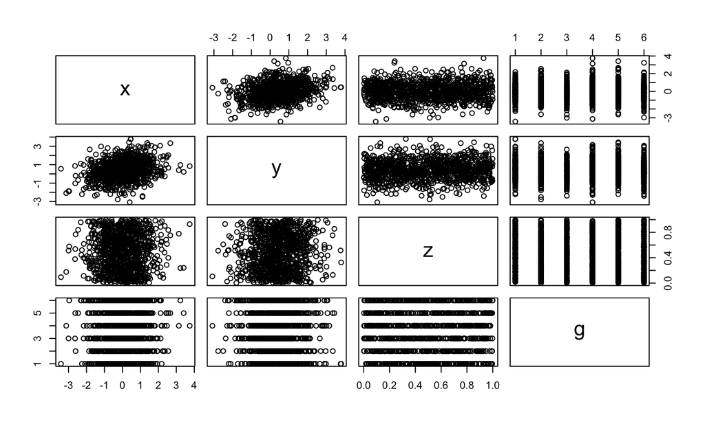

```r
pairs(my_data)
```

## `range`

Suppose you would like to find the range of a variable in your `data.frame`. The following will not work:

```r
range(my_data)
```

```
## Error in FUN(X[[i]], ...): only defined on a data frame with all numeric variables
```

Right, we cannot take the range of the entire data! Some of the variables are not numeric, and therefore do not have a range…

## `range`

Instead, we need to access one variable. There are two ways to do this.

- We can subset using square parenthesis, or
- We can use the `$` operator and access the variable of interest by name

```r
range(my_data[,1])
```

```
## [1] -3.419364  3.745572
```

```r
range(my_data$x)
```

```
## [1] -3.419364  3.745572
```

## Plots and graphs

## Introduction

- Plots are one of the great strenghts f R.
- There are two main frameworks for plotting
- Base R graphics
- `ggplot`
- Which should you use? It is a matter of preference!

## Base R plots

The basic plotting syntax is very simple. `plot(x_var, y_var)` will give you a scatter plot:

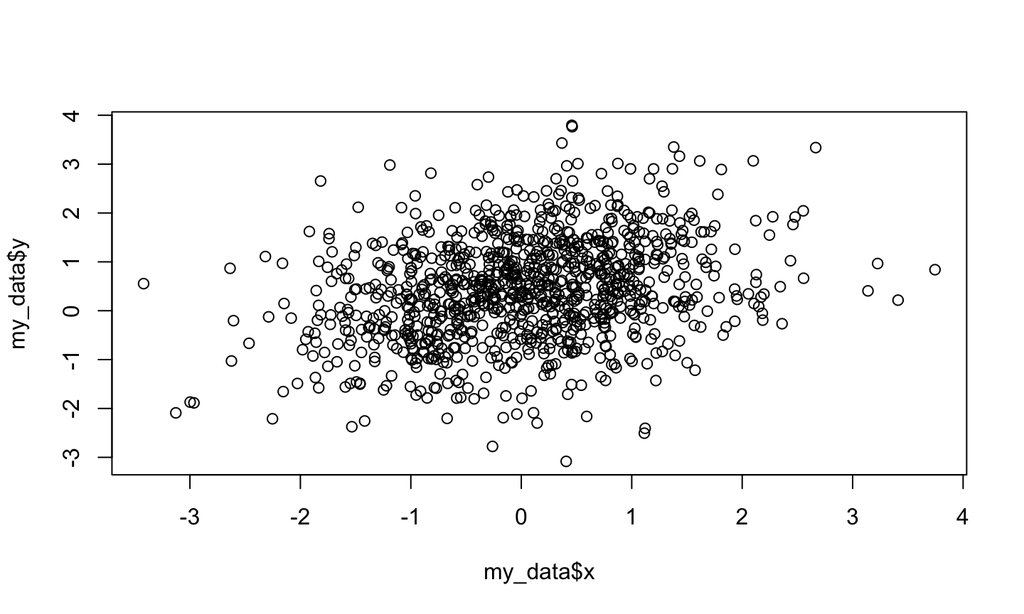

```r
plot(my_data$x, my_data$y)
```

Hmm, let's work on that.

## Base R plots

The plot function takes a number of arguments (`?plot` for a full list). The fewer you specify, the uglier your plot:

```r
plot(x = my_data$x, y = my_data$y,
     xlab = "X variable",
     ylab = "Y variable",
     main = "Awesome plot title",
     pch = 19, # Solid points
     cex = 0.5, # Smaller points
     bty = "n", # Remove surrounding box
     col = as.factor(my_data$g) # Colour by grouping variable
     )
```

## Base R plots

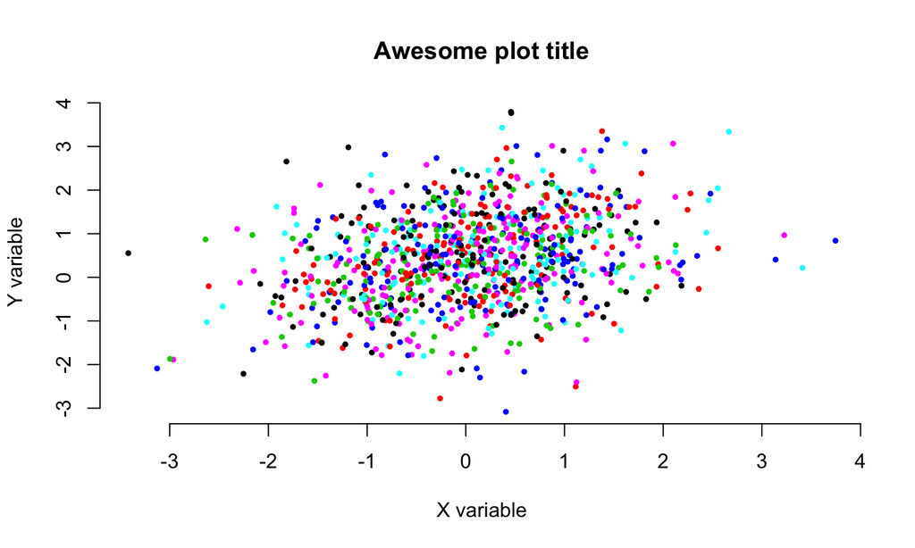

## Base R plots

The default behaviour of `plot()` depends on the type of input variables for the `x` and `y` arguments. If `x` is a factor variable, and `y` is numeric, then R will produce a boxplot:

```r
plot(x = my_data$g, y = my_data$x)
```

## Base R plots

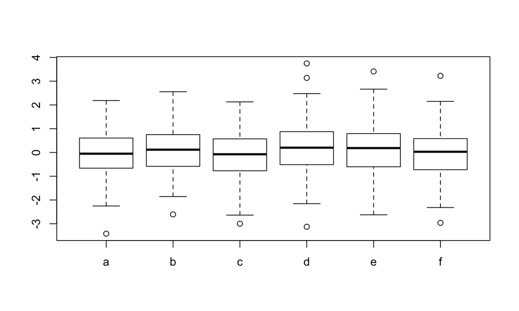

## `ggplot`

Also popular is the `ggplot2` library. This is a separate package (i.e. it is not a part of the base R environment) but is very widely used. But not by me.

- Based on the Grammar of Graphics data visualisation scheme
- Graphs are broken into scales and layers
- Has slightly idiosyncratic language style!

## `ggplot`

Let's recreate the previous scatter plot using `ggplot`:

```r
library(ggplot2)
ggplot(data = my_data, aes(x= x, y= y, col = g)) +
    geom_point() +
    xlab("X variable")+
    ylab("Y variable")+
    ggtitle("ggplot title")+
    theme(panel.background = element_rect("white"))
```

## `ggplot`

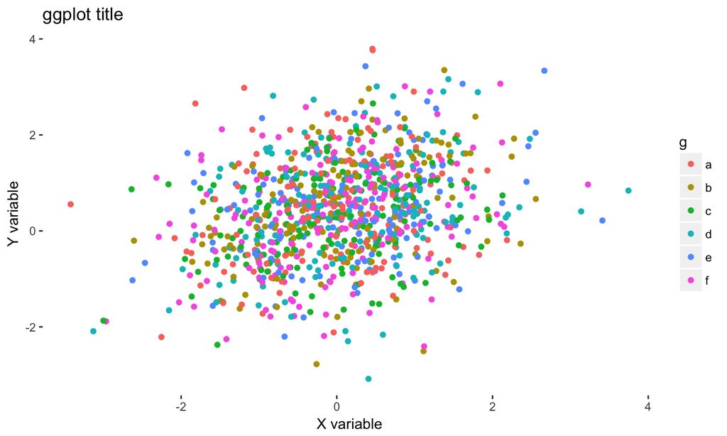

## `ggplot`

One nice feature of `ggplot` is that it is very easy to create facet plots:

```r
library(ggplot2)
ggplot(data = my_data, aes(x= x, y= y, col = g)) +
    geom_point() +
    xlab("X variable")+
    ylab("Y variable")+
    ggtitle("ggplot facet title")+
    theme(panel.background = element_rect("white"))+
    facet_wrap(~ g)
```

## `ggplot`

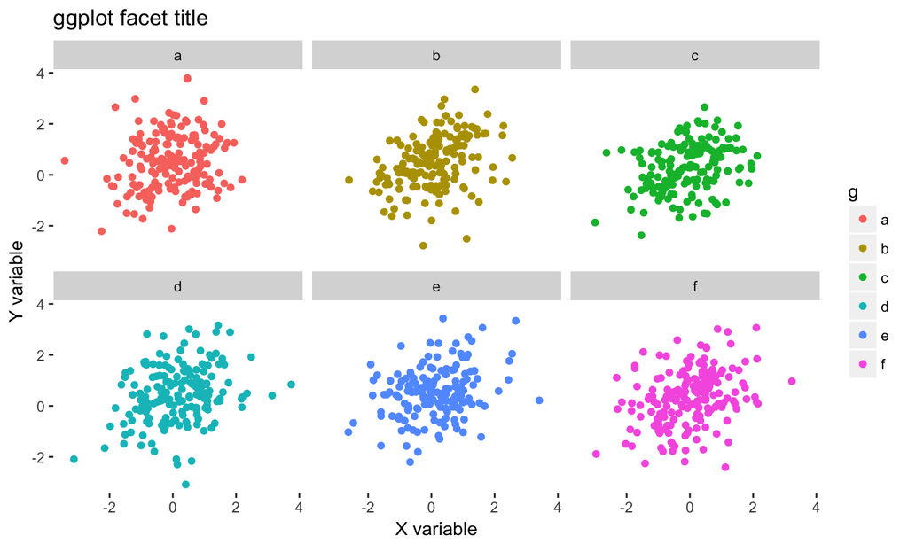

## Other examples of pretty R graphics

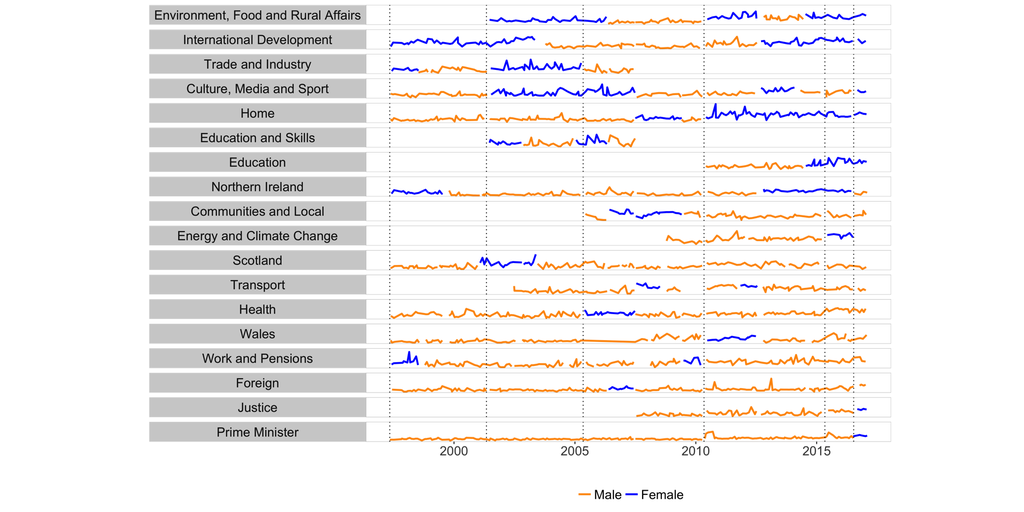

## Other examples of pretty R graphics

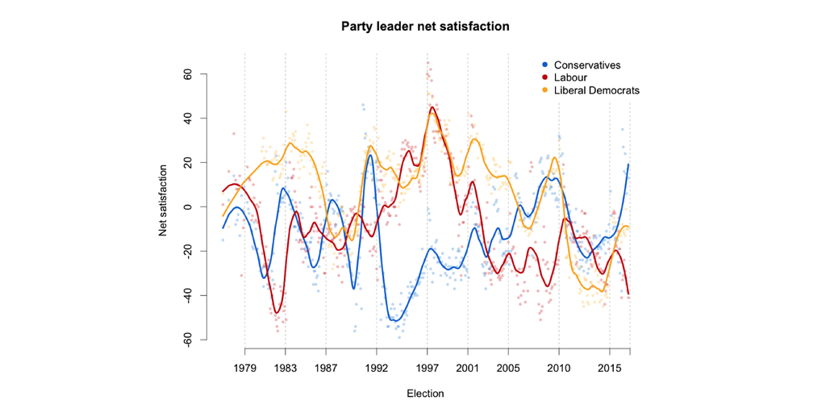

## Exercise Two

## Linear Regression Models

## `lm`

Linear regression models in R are implemented using the `lm` function.

```r
my_lm <- lm(formula = y ~ x, data = my_data)
```

The `formula` argument is the specification of the model, and the `data` argument is the data on which you would like the model to be estimated.

```r
print(my_lm)
```

```
##
## Call:
## lm(formula = y ~ x, data = my_data)
##
## Coefficients:
## (Intercept)            x
##      0.4178       0.3046
```

## `lm`

We can specify multivariate models:

```r
my_lm_multi <- lm(formula = y ~ x + z, data = my_data)
```

Interaction models:

```r
my_lm_interact <- lm(formula = y ~ x * z, data = my_data)
```

Fixed-effect models:

```r
my_lm_fe <- lm(formula = y ~ x + g, data = my_data)
```

And many more!

## `lm`

The output of the `lm` function is a long list of interesting output.

When we call `print(saved_model)`, we are presented with the estimated coefficients, and nothing else.

For some more information of the estimated model, use `summary(saved_model)`:

```r
my_lm_summary <- summary(my_lm)
print(my_lm_summary)
```

## `lm`

```
## Residuals:
##     Min      1Q  Median      3Q     Max
## -3.6246 -0.6960 -0.0202  0.7016  3.2367
##
## Coefficients:
##             Estimate Std. Error t value Pr(>|t|)
## (Intercept)  0.41777    0.03209  13.020   <2e-16 ***
## x            0.30463    0.03238   9.407   <2e-16 ***
## ---
## Signif. codes:  0 '***' 0.001 '**' 0.01 '*' 0.05 '.' 0.1 ' ' 1
##
## Residual standard error: 1.014 on 998 degrees of freedom
## Multiple R-squared:  0.08145,    Adjusted R-squared:  0.08053
## F-statistic:  88.5 on 1 and 998 DF,  p-value: < 2.2e-16
```

## `lm`

As with any other function, `summary(saved_model)` returns an object. Here, it is a list. What is saved as the output of this function?

```r
names(my_lm_summary)
```

```
##  [1] "call"          "terms"         "residuals"     "coefficients"
##  [5] "aliased"       "sigma"         "df"            "r.squared"
##  [9] "adj.r.squared" "fstatistic"    "cov.unscaled"
```

If we want to extract other information of interest from the fitted model object, we can use the `$` operator to do so:

```r
print(my_lm_summary$r.squared)
```

```
## [1] 0.08145418
```

## `lm`

Accessing elements from saved models can be very helpful in making comparisons across models:

```r
my_lm_r2 <- summary(my_lm)$r.squared
my_lm_multi_r2 <- summary(my_lm_multi)$r.squared
my_lm_interact_r2 <- summary(my_lm_interact)$r.squared

r2.compare <- data.frame(
                  model = c("bivariate", "multivariate", "interaction"),
                  r.squared = c(my_lm_r2,
                         my_lm_multi_r2,
                         my_lm_interact_r2))
```

## `lm`

We can print the values:

```r
print(r2.compare)
```

```
##          model  r.squared
## 1    bivariate 0.08145418
## 2 multivariate 0.08552710
## 3  interaction 0.09811655
```

Or we can plot them:

```r
ggplot(r2.compare, aes(x = model, y = r.squared))+
  geom_point(size = 4)+
  ggtitle("R^2 Comparison")
```

## `lm`

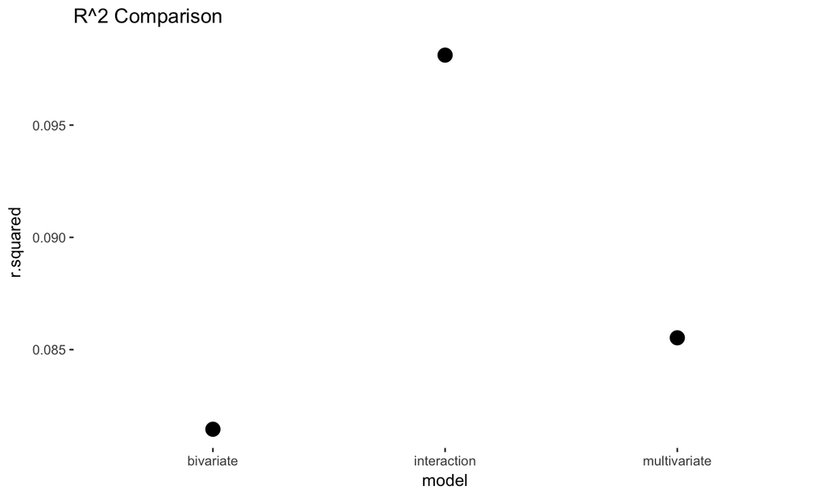

## `lm` diagnostics

There are a number of functions that are helpful in producing model diagnostics:

- `residuals(saved_model)` extracts the residuals from a fitted model
- `coefficients(saved_model)` extracts coefficients
- `fitted(saved_model)` extracts fitted values
- `plot(saved_model)` is a convenience function for producing a number of useful diagnostics plots

## `lm` residual plot

We can easily plot the residuals from a fitted model against an explanatory variable of interest:

```r
par(mfrow = c(1,2)) # Divide the plotting region into 1 row and 2 cols
plot(x = my_data$x, y = residuals(my_lm_multi),
     xlab = "x", ylab = "residuals",
     pch = 19, # Filled circles
     col="grey", # Change colour
     cex = 0.5) # Make point size smaller
abline(h = 0) # Add a horizontal line with y-intercept of 0
plot(x = my_data$z, y = residuals(my_lm_multi),
     xlab = "z", ylab = "residuals",
     pch = 19, # Filled circles
     col="grey", # Change colour
     cex = 0.5) # Make point size smaller
abline(h = 0) # Add a horizontal line with y-intercept of 0
```

## `lm` residual plot

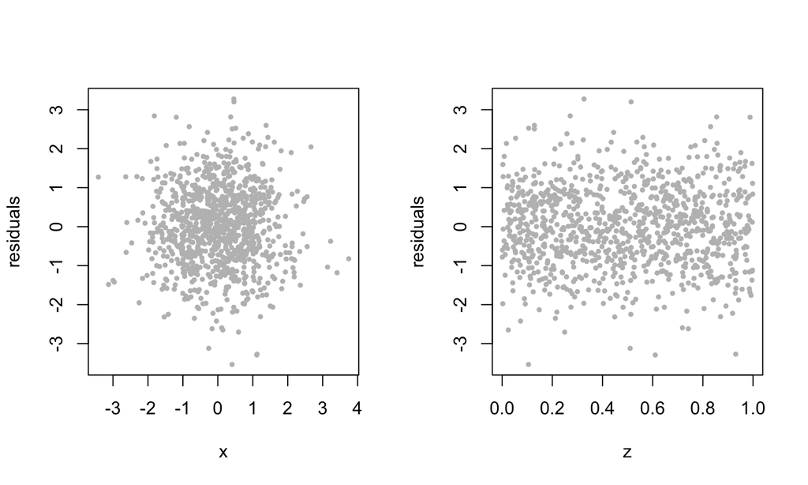

## Non-Linear Regression Models

## `glm`

To estimate a range of non-linear models, the `glm` function is particularly helpful.

First, let us transform our outcome variable from a continuous measure to a binary measure:

```r
my_data$y_bin <- as.numeric(my_data$y > median(my_data$y))
table(my_data$y_bin)
```

```
##
##   0   1
## 500 500
```

## `glm`

Now we can estimate our model:

```r
my_logit <- glm(formula = y_bin ~ x + z, data = my_data, family = "binomial")
```

Where:

- `formula` is the model specification
- `data` is the data
- `family` is a description of the error distribution and link function to be used
  - `binomial`, `poisson`, `gaussian` etc…

## `glm`

```r
summary(my_logit)
```

```
## Deviance Residuals:
##      Min        1Q    Median        3Q       Max
## -1.77744  -1.13471  -0.03837   1.14638   1.85331
##
## Coefficients:
##             Estimate Std. Error z value Pr(>|z|)
## (Intercept) -0.17079    0.12745  -1.340     0.18
## x            0.40330    0.06793   5.937  2.9e-09 ***
## z            0.32624    0.22678   1.439     0.15
## ---
## Signif. codes:  0 '***' 0.001 '**' 0.01 '*' 0.05 '.' 0.1 ' ' 1
##
## (Dispersion parameter for binomial family taken to be 1)
##
##     Null deviance: 1386.3  on 999  degrees of freedom
## Residual deviance: 1346.9  on 997  degrees of freedom
## AIC: 1352.9
##
## Number of Fisher Scoring iterations: 4
```

## `glm`

OK, but no-one actually thinks in terms of log-odds, so let's translate that into something more meaningful.

```r
my_logit_OR <- exp(cbind(OR = coef(my_logit), confint(my_logit)))
```

- `coef` extracts the coefficients
- `confint` extracts the confidence intervals
- `cbind` binds the vectors together as separate *c*olumns
- `exp` exponentiates the log-odds ratios

```r
round(my_logit_OR, digits = 4)
```

```
##                 OR  2.5 % 97.5 %
## (Intercept) 0.8430 0.6563 1.0819
## x           1.4968 1.3122 1.7129
## z           1.3858 0.8889 2.1636
```

## `glm`

Almost all of the convenience functions that we used for `lm` are also applicable to `glm` models:

```r
summary(my_logit)
plot(my_logit)
residuals(my_logit)
coefficients(my_logit)
fitted(my_logit)
```

## Other models

There are a number of external packages that can make fitting other model types (relatively) straightforward:

- `lmer4` - Linear, generalised linear, and nonlinear mixed models
- `mcgv` - generalised additive models
- `survival` - survival analysis
- `glmnet` - lasso and elastic net regression models
- `randomForest` - random forest models from machine learning
- `rjags` and `rstan` - Bayesian models

To use a package that is not a part of the base R installation, use:

```r
install.packages("survival")
library(survival)
```

## `predict`

We can retreive the fitted values from the model using `fitted()`, but we may be interested in calculating predicted values for arbitrary levels of our covariates.

```r
sim_data <- data.frame(x = c(0, 1))
y_hat <- predict(object = my_lm, newdata = sim_data)
y_hat
```

```
##         1         2
## 0.4177653 0.7223981
```

Here, I am creating a `data.frame` with two observations of one variable (`x`).

I am then using the `predict` function, where

- `object = my_lm` tells R the model object for which prediction is desired
- `newdata = sim_data` tells R the values for which I would like predictions

## `predict`

We can use the same syntax to retreive predictions for (marginally) more interesting models:

```r
sim_data <- data.frame(x = c(0, 0, 1, 1), z = c(0, 1, 0, 1))
sim_data
```

```
##   x z
## 1 0 0
## 2 0 1
## 3 1 0
## 4 1 1
```

```r
y_hat <- predict(my_lm_multi, newdata = sim_data)
y_hat
```

```
##         1         2         3         4
## 0.3027153 0.5397412 0.6072847 0.8443107
```

## `predict`

This can be especially useful when trying to visualise interactive models:

```r
sim_data_z0 <- data.frame(x = seq(from = -2, to = 2, by = 0.01), z = 0)
sim_data_z1 <- data.frame(x = seq(from = -2, to = 2, by = 0.01), z = 1)
y_hat_z0 <- predict(my_lm_interact, newdata = sim_data_z0)
y_hat_z1 <- predict(my_lm_interact, newdata = sim_data_z1)
```

- `seq` generates a regular sequences `from` one value `to` another value `by` given increments
- I am creating two `data.frame`s for prediction, in both cases varying the value of `x`, but first setting `z` to 0, and then setting `z` to 1

## `predict`

```r
# Create a plot of the data
plot(my_data$x, my_data$y, cex = 0.5, pch = 19,
     col = "gray", bty = "n",
     xlab = "X", ylab = "Y",
     main = "Fitted values for sim_data")

# Add a prediction line for z = 0
lines(x = sim_data_z0$x, y = y_hat_z0, lwd = 2)

# Add a prediction line for z = 1
lines(x = sim_data_z1$x, y = y_hat_z1, lwd = 2, col = "red")

# Add a legend
legend("bottomright", legend = c("z = 0", "z = 1"), col = c("black", "red"), lty = 1)
```

## `predict`

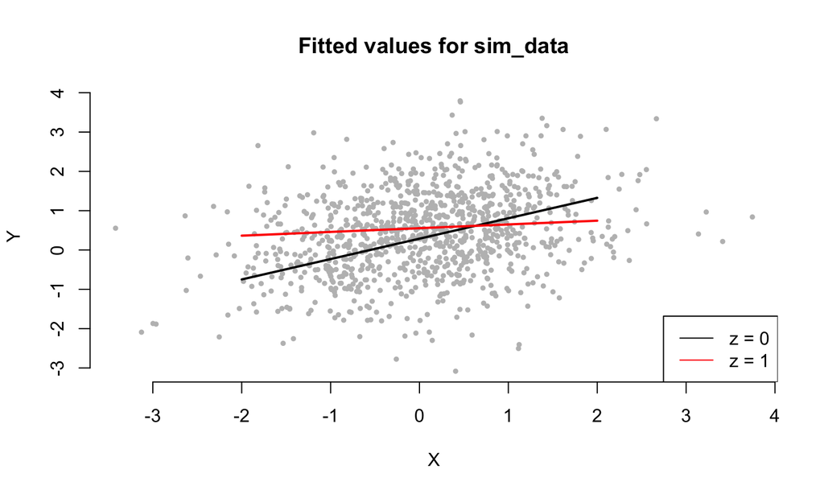

## Can we just use `margins`?

Yes! Thomas Leeper has created a nice port of STATA's `margins` command:

```r
library(margins)

cplot(my_lm_interact, x = "x", dx = "z", what = "effect")
```

`cplot` is equivalent to `marginsplot` in STATA.

The specification above tell `R` that we want to plot the marginal effect of `z` on `y` across the range of `x`.

## Can we just use `margins`?

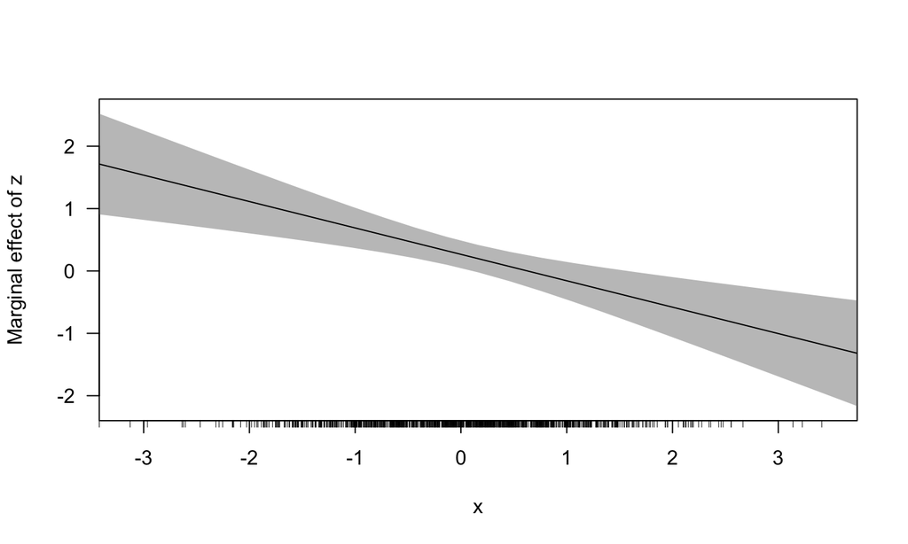

## Thank you!

## Any questions?

## Other helpful functions

```r
objects() & ls() # Which objects are currently loaded in my working environment?
rm() # Remove objects from my current environment
save() # Save R object(s) to disk
is.na() # Is this object a missing value? Or, which elements in this vector are missing?
rnorm() # Generate random numbers from a normal distribution
runif() # Generate random numbers from a uniform distribution
```

## Other helpful packages

```r
library(data.table)
library(dplyr)
library(plyr)
library(zoo)
library(reshape2)
library(shiny)
```